```python
from sklearn.linear_model import LogisticRegression
import pandas as pd
import numpy as np
from sklearn.model_selection import cross_val_score, train_test_split, GridSearchCV
import matplotlib.pyplot as plt
import matplotlib as mpl
from sklearn.metrics import accuracy_score
from sklearn.preprocessing import MinMaxScaler, PolynomialFeatures
from sklearn.feature_selection import RFE
import seaborn as sns

%matplotlib notebook
```

# Direct-Indirect Classifier

#### Leigh Weston, August 2017

Quaternary semiconductors with a zinc blende kesterite structure are promising solar absorbers for photovoltaics applications. Whether or not the band gap is direct or indirect is a fundamental property that can affect device performance.

Direct materials, while typically being stronger absorbers, have shorter carrier lifetimes and suffer from carrier recombination, and this negatively impacts efficiency in solar cells.

The best way to determine if a material is direct or indirect, is to perform high-level quantum mechanical calculations on the electronic structure. However, there are 1568 possible kesterite semiconductors, and it would be far too computationally expesnsive to perform accurate band structure calculations for all materials.

I have calculated the band gaps for a subset (n = 200) of these mataerials, and use the resutls to train a direct-indirect classifier that predicts whether a material is direct or indirect. The model is then used to make predictions for all 1568 materials.

## Read in and organize the data

I have previously generated the features and band gaps of the 200 compounds for another project, 14 were neglected as having no gap, leaving 186. The results are saved as a .csv file. I just nead to read the .csv file into a pandas data frame.

I have 15 features per compound: the electronegativity, ionic radius, and row in the periodic table for each of the four elements, as well as the column number for the cations.

```python
lr_df = pd.read_csv('quaternary_database.csv', index_col = 'Material')
lr_df.head()
```

| Material | el_1_col | el_1_neg | el_1_rad | el_1_row | el_2_col | el_2_neg | el_2_rad | el_2_row | el_4_col | el_4_neg | el_4_rad | el_4_row | el_6_neg | el_6_rad | el_6_row | a (Angst.) | c (Angst.) | Band gaps (eV) | Direct gaps (eV) |
| --- | --- | --- | --- | --- | --- | --- | --- | --- | --- | --- | --- | --- | --- | --- | --- | --- | --- | --- | --- |
| Li2CdGeSe4 | 1.0 | 0.98 | 0.59 | 2.0 | 12.0 | 1.69 | 0.78 | 5.0 | 14.0 | 2.010 | 0.39 | 5.0 | 2.55 | 1.98 | 4.0 | 5.915 | 5.915 | 2.673 | 2.673 |
| Cs2BeZrSe4 | 1.0 | 0.79 | 1.67 | 6.0 | 2.0 | 1.57 | 0.27 | 2.0 | 4.0 | 1.333 | 0.59 | 5.0 | 2.55 | 1.98 | 4.0 | 7.155 | 7.155 | 2.941 | 2.941 |
| Cu2SrGeSe4 | 11.0 | 1.90 | 0.60 | 4.0 | 2.0 | 0.95 | 1.18 | 5.0 | 14.0 | 2.010 | 0.39 | 5.0 | 2.55 | 1.98 | 4.0 | 5.802 | 5.802 | 0.935 | 0.935 |
| K2BeCSe4 | 1.0 | 0.82 | 1.37 | 4.0 | 2.0 | 1.57 | 0.27 | 2.0 | 14.0 | 2.550 | 0.15 | 2.0 | 2.55 | 1.98 | 4.0 | 6.656 | 6.656 | 2.893 | 2.927 |
| Rb2BeHfO4 | 1.0 | 0.82 | 1.52 | 5.0 | 2.0 | 1.57 | 0.27 | 2.0 | 4.0 | 1.300 | 0.58 | 6.0 | 3.44 | 1.38 | 2.0 | 5.651 | 5.651 | 5.098 | 5.098 |

The last two columns of the data frame are for the lowest band gap of the material "Band gaps (eV)", and for the lowest direct gap "Direct gaps (eV)". For direct gap materials the lowest band gap and the lowest direct gap are equal; for indirect materials, the direct gap is larger than the fundamental gap.

Next, I need to determine which of my materials are direct, and assign the result to a binary outcome. I add a column to the dataframe "Direct", and assign a value of 1 to the direct materials, and 0 to the indirect materials.

```python
dir_gap = lr_df['Direct gaps (eV)']
gap = lr_df['Band gaps (eV)']
lr_df['Direct'] =  [int(i) for i in dir_gap == gap]
lr_df.head()
```

| Material | el_1_col | el_1_neg | el_1_rad | el_1_row | el_2_col | el_2_neg | el_2_rad | el_2_row | el_4_col | el_4_neg | el_4_rad | el_4_row | el_6_neg | el_6_rad | el_6_row | a (Angst.) | c (Angst.) | Band gaps (eV) | Direct gaps (eV) | Direct |
| --- | --- | --- | --- | --- | --- | --- | --- | --- | --- | --- | --- | --- | --- | --- | --- | --- | --- | --- | --- | --- |
| Li2CdGeSe4 | 1.0 | 0.98 | 0.59 | 2.0 | 12.0 | 1.69 | 0.78 | 5.0 | 14.0 | 2.010 | 0.39 | 5.0 | 2.55 | 1.98 | 4.0 | 5.915 | 5.915 | 2.673 | 2.673 | 1 |
| Cs2BeZrSe4 | 1.0 | 0.79 | 1.67 | 6.0 | 2.0 | 1.57 | 0.27 | 2.0 | 4.0 | 1.333 | 0.59 | 5.0 | 2.55 | 1.98 | 4.0 | 7.155 | 7.155 | 2.941 | 2.941 | 1 |
| Cu2SrGeSe4 | 11.0 | 1.90 | 0.60 | 4.0 | 2.0 | 0.95 | 1.18 | 5.0 | 14.0 | 2.010 | 0.39 | 5.0 | 2.55 | 1.98 | 4.0 | 5.802 | 5.802 | 0.935 | 0.935 | 1 |
| K2BeCSe4 | 1.0 | 0.82 | 1.37 | 4.0 | 2.0 | 1.57 | 0.27 | 2.0 | 14.0 | 2.550 | 0.15 | 2.0 | 2.55 | 1.98 | 4.0 | 6.656 | 6.656 | 2.893 | 2.927 | 0 |
| Rb2BeHfO4 | 1.0 | 0.82 | 1.52 | 5.0 | 2.0 | 1.57 | 0.27 | 2.0 | 4.0 | 1.300 | 0.58 | 6.0 | 3.44 | 1.38 | 2.0 | 5.651 | 5.651 | 5.098 | 5.098 | 1 |

```python
print('The number of direct gap materials is: {}'.format(lr_df['Direct'].sum()))
print('The number of indirect gap materials is: {}'.format(len(lr_df['Direct']) - lr_df['Direct'].sum()))
```

```
The number of direct gap materials is: 78
The number of indirect gap materials is: 108
```

Finally, I extract the features and binary outcomes to fit the model.

```python
X = lr_df.iloc[:, :15].as_matrix()
y = lr_df['Direct']
```

## Fitting the model

Logistic regression has parameters that can be tuned. First of all, I just want to see how the model works with the default parameters and using the most basic features.

I can separate the data into training and test sets, and train the model so see the accuracy of the predictions.

```python
X_train, X_test, y_train, y_test = train_test_split(X, y)
clf = LogisticRegression().fit(X_train, y_train)
print('Score on training set: {}.'.format(accuracy_score(y_train, clf.predict(X_train))))
print('Score on training set: {}.'.format(accuracy_score(y_test, clf.predict(X_test))))
```

```
Score on training set: 0.7266187050359713.
Score on training set: 0.7446808510638298.
```

The default settings gave an accuracy score of 74% on the test set based on a single split of the data. Performing cross-validation will give a better indication as to the accuracy of the model.

```python
scores = cross_val_score(LogisticRegression(), X, y, cv = 10)
print('Classifier accuracy scores based on 5-fold cross validation: {}'.format(scores))
print('Mean classifier score: {}'.format(scores.mean()))
```

```
Classifier accuracy scores based on 5-fold cross validation: [ 0.52631579  0.84210526  0.57894737  0.84210526  0.73684211  0.68421053
  0.73684211  0.73684211  0.64705882  0.70588235]
Mean classifier score: 0.7037151702786378
```

I can tune regularization parameter $C$ in the classifier to improve predictions using grid search.

```python
params = {'C': np.logspace(-2, 2, 20)}
log_reg_gs = GridSearchCV(LogisticRegression(), params, cv = 10)
gs_result = log_reg_gs.fit(X, y)
```

```python
print('Grid search best params: {}'.format(gs_result.best_params_))
print('Grid search best score: {}'.format(gs_result.best_score_))
```

```
Grid search best params: {'C': 5.4555947811685144}
Grid search best score: 0.7311827956989247
```

Tuning the regularization parameter $C$ only gave a modest improvement in the predictions. It would be desirebale to have a more accurate classifier.

One option is to use feature engineering.

## Feature engineering

#### Polynomial features

One possibility to improve the accuracy of the classifier is to use feature engineering.

I use polynomial features to generate a new feature matrix with all polynomial combinations of the original features. I use polynomial features of order 2.

```python
poly2 = PolynomialFeatures(2)
X_poly = poly2.fit_transform(X)
```

Since I am adding new features, the model is susceptible to overfitting. I need to use grid search to reoptimize the regularization paramater.

To assess any improvement in the classifier, I do grid search with 10-fold cross validation.

```python
params_poly = {'C': np.logspace(-3, 0, 50)}
grid_poly = GridSearchCV(LogisticRegression(), params_poly, cv = 10)
result_poly = grid_poly.fit(X_poly, y)
```

```python
print('Grid search best params: {}'.format(result_poly.best_params_))
print('Grid search best score: {}'.format(result_poly.best_score_))
```

```
Grid search best params: {'C': 0.039069399370546168}
Grid search best score: 0.8279569892473119
```

Using polynomial features substantially improved the accuracy of the classifier, with an accuracy of 83% achieved. This result is probably already good enough to aid in materials design, however it would be good to have further improvement.

I could try a higher order polynomial, however this risks over fitting.

```python
poly3 = PolynomialFeatures(3)
X_poly3 = poly3.fit_transform(X)
params_3 = {'C': np.logspace(-8, 0, 20)}
grid_poly3 = GridSearchCV(LogisticRegression(), params_3, cv = 10)
results_poly3 = grid_poly3.fit(X_poly3, y)
```

```python
print('Grid search best params: {}'.format(results_poly3.best_params_))
print('Grid search best score: {}'.format(results_poly3.best_score_))
```

```
Grid search best params: {'C': 2.3357214690901213e-05}
Grid search best score: 0.8172043010752689
```

Unfortunately, including a higher-order polynomial did not improve the results - this is probably due to overfitting.

#### Feature selection

The results for a 3rd order polynomial indicated overfitting. One way to overcome this, while still having the advantage of keeping some higher-order terms, is to use feature selection.

I take the feature space, which contains over 800 features per compound, and use recursive feature elimination to prune features of a low importance, leaving a mcuh smaller feature space,however with features with a degree of importance.

It is not known $a\ priori$ how large of a subset of we should select. The code below loops over possible subset sizes, and does a grid search on the new feature space to optimize a new classifier; the best $C$ parameter and best classification accuracy score are reported.

```python
df_poly3 = pd.DataFrame(X_poly3)
params_fs = {'C': np.logspace(-6, 0, 7)}
best_score = 0
for num_features in np.arange(10, 110, 20):
    rfe_new = RFE(LogisticRegression(), num_features)
    fit_features = rfe_new.fit(X_poly3, y)

    new_features = pd.DataFrame()
    for feature in np.where(fit_features.ranking_ == 1):
        new_features = pd.concat([new_features, df_poly3.iloc[:, feature]], axis = 0)

    X_fitted = new_features.as_matrix()
    grid = GridSearchCV(LogisticRegression(), params_fs, cv = 10)
    results_search = grid.fit(X_fitted, y)

    print('Grid search best params for {} features: {}'.format(num_features, results_search.best_params_))
    print('Grid search best score for {} features: {}'.format(num_features, results_search.best_score_, sep = '\n'))

    if results_search.best_score_ > best_score:
        best_score = results_search.best_score_
        best_params = results_search.best_params_
        best_feature_size = num_features
        best_features_array = np.where(fit_features.ranking_ == 1)
        best_features = X_fitted

print('The best score is: {}'.format(best_score))
print('The best C parameter is: {}'.format(best_params))
print('The best size for the feature set is: {}'.format(best_feature_size))
print('Vector of best features: {}'.format(best_features_array))
print('The best features for the training data have been saved to the variable "X_fitted"')
```

```
Grid search best params for 10 features: {'C': 1.0}
Grid search best score for 10 features: 0.7043010752688172
Grid search best params for 30 features: {'C': 0.10000000000000001}
Grid search best score for 30 features: 0.8870967741935484
Grid search best params for 50 features: {'C': 0.01}
Grid search best score for 50 features: 0.8817204301075269
Grid search best params for 70 features: {'C': 0.10000000000000001}
Grid search best score for 70 features: 0.8548387096774194
Grid search best params for 90 features: {'C': 0.0001}
Grid search best score for 90 features: 0.8333333333333334
The best score is: 0.8870967741935484
The best C parameter is: {'C': 0.10000000000000001}
The best size for the feature set is: 30
Vector of best features: (array([250, 329, 362, 374, 382, 383, 421, 423, 427, 446, 452, 456, 457,
       461, 478, 487, 498, 502, 508, 523, 524, 526, 616, 668, 722, 735,
       750, 753, 799, 803]),)
The best features for the training data have been saved to the variable "X_fitted"
```

Using a combination of feature engineering and feature selection, I was able to significantly improve the accuracy of the classifier. Without feature selection, the classifier had an accuracy score of 81.7%; by pruning all but the 30 best features, I was able to acheive an accuracy score of 88.7%.

I did tests for higher order polynomials (not shown here, I had to do them on a supercomputing cluster to prune such a a large feature space).

89% is the best I can achieve; better results would most likely require a larger training set.

## Make predictions and vizualize

Having optimized the classifier and the feature space, the final step is to visualize my predictions, and save them for later use.

First, I need to generate the optimized features for all 1568 compounds.

For another preject, I previously saved a list of all possible compounds and their descriptors within the simple 15-dimensional feature space. I saved the file in csv format in a file named 'ALL_GAPS.csv', I can read it into a dataframe to extract the material names and features.

```python
df_all = pd.read_csv('ALL_GAPS.csv', index_col = 'Material')
X_all = df_all.iloc[:,:-1].as_matrix()
```

```python
X_all_poly3 = poly3.fit_transform(X_all)
df_all_poly3 = pd.DataFrame(X_all_poly3)
df_all_poly3_opt = pd.DataFrame()
for feature in best_features_array:
    df_all_poly3_opt = pd.concat([df_all_poly3_opt, df_all_poly3.iloc[:, feature]], axis = 0)
X_all_opt = df_all_poly3_opt.as_matrix()
```

#### Make predictions

With the features optimized for all possible compounds, next is to train an optimized classifier using the optimized C parameter and features. Then, I make the predictions for all possible compounds. I save the predicted results for safe keeping.

```python
clf_opt = LogisticRegression(C = best_params['C'])
opt_classifier = clf_opt.fit(best_features, y)
gap_predictions = opt_classifier.predict(X_all_opt)
df_all['Direct'] = gap_predictions
df_all.to_csv('gap_classifier.csv')
df_all.head()
```

| Material | el_1_col | el_1_neg | el_1_rad | el_1_row | el_2_col | el_2_neg | el_2_rad | el_2_row | el_4_col | el_4_neg | el_4_rad | el_4_row | el_6_neg | el_6_rad | el_6_row | Band gap (eV) | Direct |
| --- | --- | --- | --- | --- | --- | --- | --- | --- | --- | --- | --- | --- | --- | --- | --- | --- | --- |
| Li2BeCO4 | 1.0 | 0.98 | 0.59 | 2.0 | 2.0 | 1.57 | 0.27 | 2.0 | 14.0 | 2.55 | 0.15 | 2.0 | 3.44 | 1.38 | 2.0 | 4.977532 | 0 |
| Li2BeCS4 | 1.0 | 0.98 | 0.59 | 2.0 | 2.0 | 1.57 | 0.27 | 2.0 | 14.0 | 2.55 | 0.15 | 2.0 | 2.58 | 1.84 | 3.0 | 3.374164 | 1 |
| Li2BeCSe4 | 1.0 | 0.98 | 0.59 | 2.0 | 2.0 | 1.57 | 0.27 | 2.0 | 14.0 | 2.55 | 0.15 | 2.0 | 2.55 | 1.98 | 4.0 | 2.611518 | 1 |
| Li2BeCTe4 | 1.0 | 0.98 | 0.59 | 2.0 | 2.0 | 1.57 | 0.27 | 2.0 | 14.0 | 2.55 | 0.15 | 2.0 | 2.10 | 2.21 | 3.0 | 1.346567 | 1 |
| Li2BeSiO4 | 1.0 | 0.98 | 0.59 | 2.0 | 2.0 | 1.57 | 0.27 | 2.0 | 14.0 | 1.90 | 0.26 | 3.0 | 3.44 | 1.38 | 2.0 | 5.565135 | 0 |

#### Plots results

Now that I have made the predictions, the final step is to vizualize the trends for the different anions in each compound.

```python
oxides     = df_all[ df_all.index.str[-2:]  == 'O4' ].iloc[:, -1]
sulfides   = df_all[ df_all.index.str[-2:]  == 'S4' ].iloc[:, -1]
selenides  = df_all[ df_all.index.str[-3:]  == 'Se4' ].iloc[:, -1]
tellurides = df_all[ df_all.index.str[-3:]  == 'Te4' ].iloc[:, -1]

oxides_gap = [sum(oxides), len(oxides) - sum(oxides)]
sulfides_gap = [sum(sulfides), len(sulfides) - sum(sulfides)]
selenides_gap = [sum(selenides), len(selenides) - sum(selenides)]
tellurides_gap = [sum(tellurides), len(tellurides) - sum(tellurides)]
```

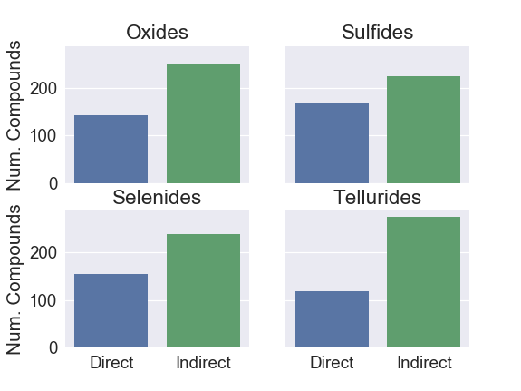

```python
#print('The number of direct materials: {}'.format(sum(df_all['Direct'])))
#print('The number of indirect materials: {}'.format(len(df_all['Direct']) - sum(df_all['Direct'])))
sns.set(font_scale=1.5)
f, ([ax1, ax2], [ax3, ax4]) = plt.subplots(2, 2, sharex=True, sharey = True)
names = ['Oxides', 'Sulfides', 'Selenides', 'Tellurides']
gap_list = [oxides_gap, sulfides_gap, selenides_gap, tellurides_gap]
for axis, gaps, name in zip([ax1, ax2, ax3, ax4], gap_list, names):
    sns.barplot(['Direct', 'Indirect'], gaps, ax=axis)
    axis.set_title(name)

ax1.set_ylabel('Num. Compounds')
ax3.set_ylabel('Num. Compounds')
plt.savefig('gaps_classified.pdf')
```

It is clear that there are more indirect gap materials than indirect. The largest different is for the tellurides, the smallest for the sulfides.